# Chapter 3 Practice Problems

```r
library(faraway)
```

## 1.

For the prostatedata, fit a model with lpsaas the response and the other vari- ables as predictors:

```r
data("prostate")
pro.fit <- lm(lpsa ~ ., data = prostate)
```

**(a) Compute 90 and 95% CIs for the parameter associated with age. Using just** **these intervals, what could we have deduced about the p-value for age in the** **regression summary?**

```r
confint(pro.fit, level = .9)[4, ]
```

```
##          5 %         95 %
## -0.038210200 -0.001064151
```

```r
confint(pro.fit, level = .95)[4, ]
```

```
##        2.5 %       97.5 %
## -0.041840618  0.002566267
```

From the output, we can deduce that the age parameter is not statistically significant at the the 95% confidence level, because the interval contains 0. However, it is at the 90% confidence level, because it doesn’t contain 0.

**(b) Compute and display a 95% joint confidence region for the parameters asso-** **ciated with age and lbph. Plot the origin on this display. The location of the** **origin on the display tells us the outcome of a certain hypothesis test. State that** **test and its outcome.**

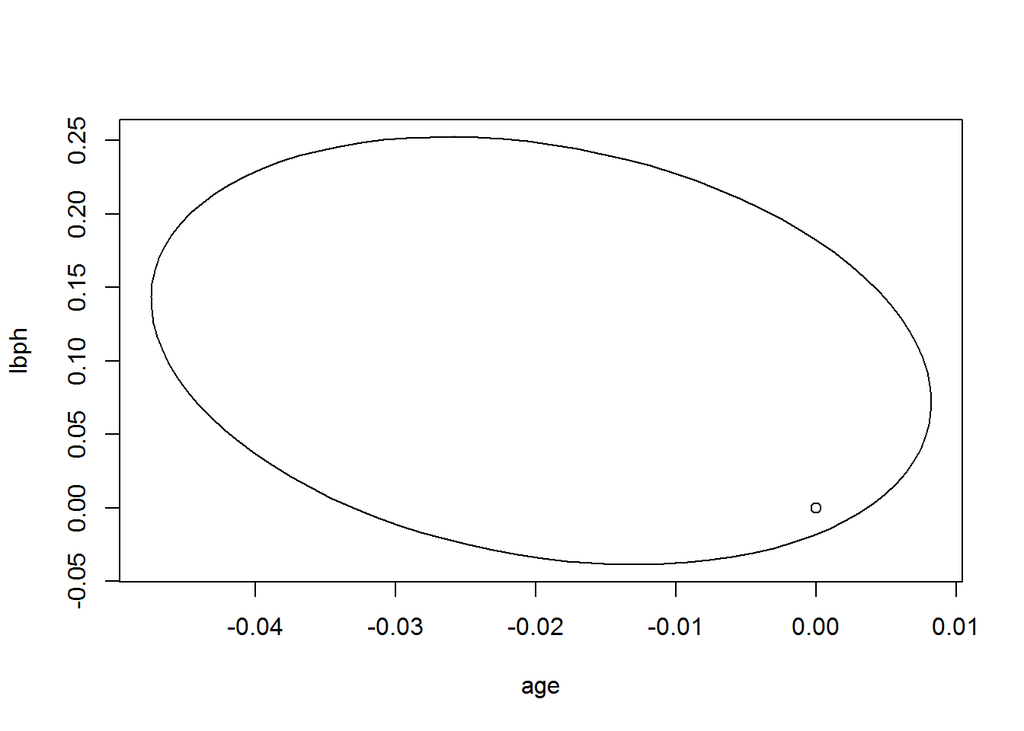

```r
library(ellipse)
plot(ellipse(pro.fit, c(4, 5)), type = "l")
points(0, 0)
```

This test corresponds to:

$$H_0: \beta_{lbph} = \beta_{age} = 0 |\ \textrm{The other regressors are in the model}$$
And since the point is inside the ellipse, we must fail to reject the null hypothesis and claim that the age and lbph regression coefficients could be 0.

**(c) In the text, we made a permutation test corresponding to the F-test for the** **significance of all the predictors. Execute the permutation test corresponding** **to the t-test for age in this model. (Hint: {summary(g)$coef[4,3] gets you** **the t-statistic you need if the model is called g.)**

```r
n <- 1000
obs <- summary(pro.fit)$coef[4, 3]
tstat <- vector("numeric", length = n)

for (i in 1:n) {
  mod <- lm(lpsa ~ lcavol + lweight + sample(age) + lbph + svi + lcp + gleason +  pgg45, data = prostate)
  tstat[i] <- summary(mod)$coef[4, 3]
}

mean(abs(tstat) > abs(obs))
```

```
## [1] 0.083
```

**(d) Remove all the predictors that are not significant at the 5% level. Test this** **model against the original model. Which model is preferred?**

```r
summary(pro.fit)
```

```
##
## Call:
## lm(formula = lpsa ~ ., data = prostate)
##
## Residuals:
##     Min      1Q  Median      3Q     Max
## -1.7331 -0.3713 -0.0170  0.4141  1.6381
##
## Coefficients:
##              Estimate Std. Error t value Pr(>|t|)
## (Intercept)  0.669337   1.296387   0.516  0.60693
## lcavol       0.587022   0.087920   6.677 2.11e-09 ***
## lweight      0.454467   0.170012   2.673  0.00896 **
## age         -0.019637   0.011173  -1.758  0.08229 .
## lbph         0.107054   0.058449   1.832  0.07040 .
## svi          0.766157   0.244309   3.136  0.00233 **
## lcp         -0.105474   0.091013  -1.159  0.24964
## gleason      0.045142   0.157465   0.287  0.77503
## pgg45        0.004525   0.004421   1.024  0.30886
## ---
## Signif. codes:  0 '***' 0.001 '**' 0.01 '*' 0.05 '.' 0.1 ' ' 1
##
## Residual standard error: 0.7084 on 88 degrees of freedom
## Multiple R-squared:  0.6548, Adjusted R-squared:  0.6234
## F-statistic: 20.86 on 8 and 88 DF,  p-value: < 2.2e-16
```

From the above output, we can see that the age, lbph, lcp, gleason, and pgg45 regressors are not significant at the 5% level.

```r
pro.lil <- lm(lpsa ~ lcavol + lweight + svi, data = prostate)
anova(pro.lil, pro.fit)
```

```
## Analysis of Variance Table
##
## Model 1: lpsa ~ lcavol + lweight + svi
## Model 2: lpsa ~ lcavol + lweight + age + lbph + svi + lcp + gleason +
##     pgg45
##   Res.Df    RSS Df Sum of Sq      F Pr(>F)
## 1     93 47.785
## 2     88 44.163  5    3.6218 1.4434 0.2167
```

From the above test, we get an F-statistic of 1.4434, and a p-value or .2167. Thus, we must fail to reject the null, in this case that the age, lbph, lcp, gleason, and pgg45 regression coefficents are 0. Thus, these regressors do not need to be in our model.

### 3.

Using the teengambdata, fit a model with gambleas the response and the other variables as predictors.

```r
data("teengamb")
gamb.fit <- lm(gamble ~ ., data = teengamb)
```

**(a) Which variables are statistically significant at the 5% level?**

```r
summary(gamb.fit)
```

```
##
## Call:
## lm(formula = gamble ~ ., data = teengamb)
##
## Residuals:
##     Min      1Q  Median      3Q     Max
## -51.082 -11.320  -1.451   9.452  94.252
##
## Coefficients:
##              Estimate Std. Error t value Pr(>|t|)
## (Intercept)  22.55565   17.19680   1.312   0.1968
## sex         -22.11833    8.21111  -2.694   0.0101 *
## status        0.05223    0.28111   0.186   0.8535
## income        4.96198    1.02539   4.839 1.79e-05 ***
## verbal       -2.95949    2.17215  -1.362   0.1803
## ---
## Signif. codes:  0 '***' 0.001 '**' 0.01 '*' 0.05 '.' 0.1 ' ' 1
##
## Residual standard error: 22.69 on 42 degrees of freedom
## Multiple R-squared:  0.5267, Adjusted R-squared:  0.4816
## F-statistic: 11.69 on 4 and 42 DF,  p-value: 1.815e-06
```

From the output, we can see that the sex and income variables are significant at the 5% level.

**(b) What interpretation should be given to the coefficient for sex?** With similar values for the other regressors, we would expect that on average a female will gamble $22.12 less each year than a male counterpart.

**(c) Fit a model with just incomeas a predictor and use an F-test to compare it to the full model.**

```r
gamb.lil <- lm(gamble ~ income, data = teengamb)
anova(gamb.lil, gamb.fit)
```

```
## Analysis of Variance Table
##
## Model 1: gamble ~ income
## Model 2: gamble ~ sex + status + income + verbal
##   Res.Df   RSS Df Sum of Sq      F  Pr(>F)
## 1     45 28009
## 2     42 21624  3    6384.8 4.1338 0.01177 *
## ---
## Signif. codes:  0 '***' 0.001 '**' 0.01 '*' 0.05 '.' 0.1 ' ' 1
```

From the output, we can see that our F-statistic is 4.1338 and our p-value is .01177. Our null hypothesis in this case is:

$$H_0: \beta_{sex} = \beta_{status} = \beta_{verbal} = 0 | \textrm{The income regressor is included}$$

With the p-value received, we have strong evidence to reject the null hypothesis, and shold claim that at least one of the other regressors should be included in our model.

### 4.

```r
data("sat")
sat.fit <- lm(total ~ expend + ratio + salary, data = sat)
sat.lil <- lm(total ~ expend + ratio, data = sat)
anova(sat.lil, sat.fit)
```

```
## Analysis of Variance Table
##
## Model 1: total ~ expend + ratio
## Model 2: total ~ expend + ratio + salary
##   Res.Df    RSS Df Sum of Sq      F  Pr(>F)
## 1     47 233443
## 2     46 216812  1     16631 3.5285 0.06667 .
## ---
## Signif. codes:  0 '***' 0.001 '**' 0.01 '*' 0.05 '.' 0.1 ' ' 1
```

From this output, we can see that the our F-statistic is 3.5285 and our p-value is .06667. Thus, we don’t have enough evidence to reject the null hypothesis, and we should claim that the `salary` variable’s regression coefficient could be 0.

```r
sat.null <- lm(total ~ 1, data = sat)
anova(sat.null, sat.fit)
```

```
## Analysis of Variance Table
##
## Model 1: total ~ 1
## Model 2: total ~ expend + ratio + salary
##   Res.Df    RSS Df Sum of Sq      F  Pr(>F)
## 1     49 274308
## 2     46 216812  3     57496 4.0662 0.01209 *
## ---
## Signif. codes:  0 '***' 0.001 '**' 0.01 '*' 0.05 '.' 0.1 ' ' 1
```

Fromt the above test, we received a F-statistic of 4.0662 and a p-value of .01209. Thus, we have moderate eveidence that we should reject the null hypothesis, and claim that these regressors do have some effect on the response.

```r
sat.full <- lm(total ~ expend + ratio + salary + takers, data = sat)
anova(sat.fit, sat.full)
```

```
## Analysis of Variance Table
##
## Model 1: total ~ expend + ratio + salary
## Model 2: total ~ expend + ratio + salary + takers
##   Res.Df    RSS Df Sum of Sq      F    Pr(>F)
## 1     46 216812
## 2     45  48124  1    168688 157.74 2.607e-16 ***
## ---
## Signif. codes:  0 '***' 0.001 '**' 0.01 '*' 0.05 '.' 0.1 ' ' 1
```

From this test, we get a F-statistic of 157.75 and a p-value of practically 0. We have thus have very strong evidence to reject the null hypothesis, and claim that the `takers` variable should be included in our model.

```r
t <- summary(sat.full)$coef[5, 1] / summary(sat.full)$coef[5, 2]
t^2
```

```
## [1] 157.7379
```

From this, we can see that the t-test and the F-test result in the same statistic.